# Tutorial 3: Week 6

Brittany Blankinship

27-10-2021

```r
library(tidyverse)
library(prettydoc) #for other theme options
library(rmdformats) #for other theme options
library(gapminder) #for our data
library(knitr) #for report generation
library(kableExtra) #for pretty tables

#save the gapminder data into the working environment & create some variables for analysis
mydata <- gapminder %>%
  # round gdpPercap to 0 decimals:
  mutate(gdpPercap = round(gdpPercap)) %>%
  # divide pop by million, round to 1 decimal:
  mutate(pop_millions = (pop/1e6) %>% round(1))

# correlation for inline code example below
LePcor <- cor.test(mydata$lifeExp, mydata$pop)
```

# Tables

When making tables, it is a good idea to use the `kable()` function from the `knitr` package to produce nice looking tables rather than the usual r output.

Compare this table output:

```r
mydata %>%
  select(-pop) %>%
  sample_n(10)
```

```
## # A tibble: 10 × 6
##    country            continent  year lifeExp gdpPercap pop_millions
##    <fct>              <fct>     <int>   <dbl>     <dbl>        <dbl>
##  1 West Bank and Gaza Asia       2007    73.4      3025          4
##  2 Argentina          Americas   2007    75.3     12779         40.3
##  3 Ghana              Africa     1992    57.5       925         16.3
##  4 Nigeria            Africa     2002    46.6      1615        120.
##  5 Vietnam            Asia       1952    40.4       605         26.2
##  6 Hungary            Europe     1962    68.0      7550         10.1
##  7 Croatia            Europe     1962    67.1      5478          4.1
##  8 Hong Kong, China   Asia       1997    80       28378          6.5
##  9 Benin              Africa     1972    47.0      1086          2.8
## 10 Egypt              Africa     1967    49.3      1815         31.7
```

To this one:

```r
mydata %>%
  select(-pop) %>%
  sample_n(10) %>%
  kable()
```

| country | continent | year | lifeExp | gdpPercap | pop_millions |
| --- | --- | --- | --- | --- | --- |
| Netherlands | Europe | 1967 | 73.82000 | 15363 | 12.6 |
| Equatorial Guinea | Africa | 2007 | 51.57900 | 12154 | 0.6 |
| Morocco | Africa | 1952 | 42.87300 | 1688 | 9.9 |
| Morocco | Africa | 2007 | 71.16400 | 3820 | 33.8 |
| Gambia | Africa | 1982 | 45.58000 | 836 | 0.7 |
| Saudi Arabia | Asia | 1962 | 45.91400 | 11626 | 4.9 |
| Oman | Asia | 1962 | 43.16500 | 2925 | 0.6 |
| Mexico | Americas | 1987 | 69.49800 | 8688 | 80.1 |
| Sierra Leone | Africa | 2002 | 41.01200 | 699 | 5.4 |
| China | Asia | 1977 | 63.96736 | 741 | 943.5 |

For further styling options, the [`kableExtra` package](https://haozhu233.github.io/kableExtra/awesome_table_in_html.html#Overview) can help!

When using an HTML document/table, even just including one more line of code significantly improves the formatting. There are 6 additional alternative HTML table theme options apart from the default bootstap theme:

- `kable_styling()` for the bookstrap theme
1. `kable_classic()`
2. `kable_classic2()`
3. `kable_paper()`
4. `kable_minimal()`
5. `kable_material()`
6. `kable_material_dark()`

```r
mydata %>%
  select(-pop) %>%
  sample_n(10) %>%
  kable() %>%
  kable_styling(bootstrap_options = "striped", full_width = F)
```

| country | continent | year | lifeExp | gdpPercap | pop_millions |
| --- | --- | --- | --- | --- | --- |
| Nepal | Asia | 1952 | 36.157 | 546 | 9.2 |
| Bahrain | Asia | 1982 | 69.052 | 19211 | 0.4 |
| Paraguay | Americas | 1967 | 64.951 | 2299 | 2.3 |
| Mauritania | Africa | 1987 | 56.145 | 1422 | 1.8 |
| France | Europe | 1987 | 76.340 | 22066 | 55.6 |
| Belgium | Europe | 1957 | 69.240 | 9715 | 9.0 |
| Guinea | Africa | 1992 | 48.576 | 794 | 7.0 |
| Lebanon | Asia | 1952 | 55.928 | 4835 | 1.4 |
| Tunisia | Africa | 2007 | 73.923 | 7093 | 10.3 |
| Montenegro | Europe | 1977 | 73.066 | 9596 | 0.6 |

The majority of `kableExtra` functions will work in [both HTML and PDF knitted files](https://github.com/haozhu233/kableExtra#basic-usage). When using a PDF file, you need to use the argument `latex_options` instead as you are producing LaTeX tables.

# Figures

You can easily integrate figures into your report as well using a code chunk dedicated to the figure of interest.

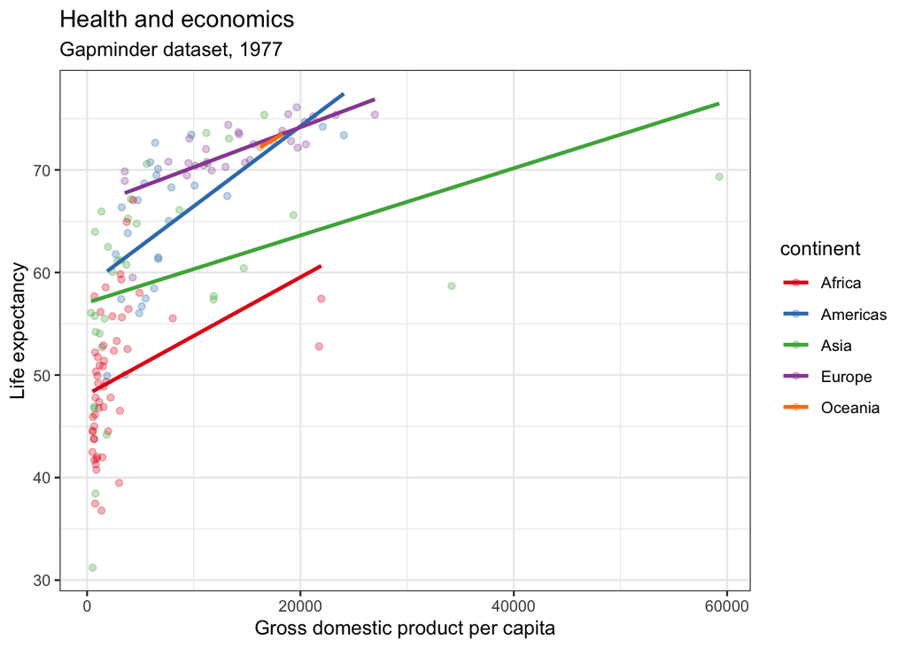

```r
mydata %>%
  filter(year == 1977) %>%
  ggplot(aes(y = lifeExp, x = gdpPercap, colour = continent)) +
  geom_point(alpha = 0.3) +
  theme_bw() +
  geom_smooth(method = "lm", se = FALSE) +
  scale_colour_brewer(palette = "Set1") +
  labs(x = "Gross domestic product per capita",
       y = "Life expectancy",
       title = "Health and economics",
       subtitle = "Gapminder dataset, 1977")
```

# Images

You can easily insert images into your R Markdown file either from a webpage or from a file in the same directory:

1. From a webpage

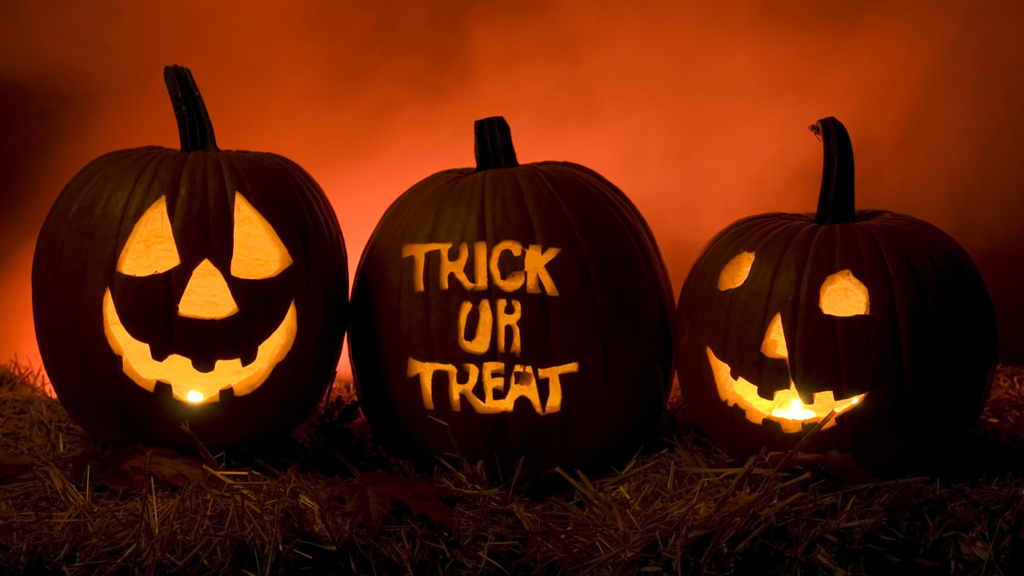

To get the link to a picture from a webpage go to your internet browser of choice, Images, and right click on the image and select “Copy Image Link”.

2. From a file

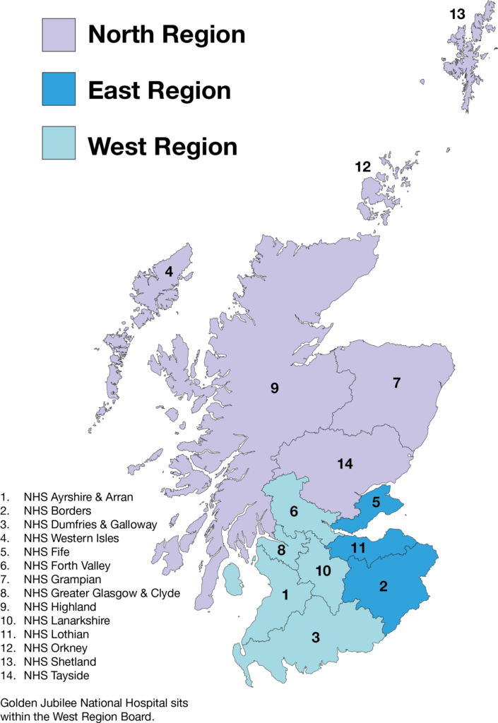

NHS Scotland HBs

# Inline Code

You can also use r code directly in text. For example:

> There are 1704 observations in the data set.

This can be an incredible time saver if you are creating a report where the data itself might still be coming in. Rather than needing to manually update descriptive information such as how many observations there are in the data set, let R do it for you!

I also will often use this when reporting in text results of analyses. For example:

> The correlation between life expectancy and population is $r$(1702) = 0.065, $p$ = 0.007

## Mathematical notation

You will notice above that I used something else in combination with the inline r code - mathematical notation! This is based on LaTeX. In side a text chunk, you can use mathematical notation if you surround it by dollar signs `$` for “inline mathematics” and `$$` for “displayed equations”. [This post by R Pruim](https://rpruim.github.io/s341/S19/from-class/MathinRmd.html) is my go-to resource for mathematical notation in R Markdown.

# Functionalities

## HTML

In general, I find that when knitting to an `html_document` there are more interesting functionalities. Indeed, Markdown was originally designed for HTML output so the HTML format has the richest features.

- floating table of contents
- code download output option
- code folding (hide or show)
- tabbed sections

You can have a look at some of the other options when knitting to HTML in the [HTML document chapter in R Markdown: The Definitive Guide](https://bookdown.org/yihui/rmarkdown/html-document.html#appearance-and-style)

Chunk names are not necessarily required to knit, but are good practice and help to support more advanced knitted approaches. Chunk labels should be

- unique
- do not use spaces, rather use dashes (-)
- use alphanumeric characters (a-z, A-Z and 0-9), because they are not special characters and will surely work for all output formats
- spaces and underscores in particular, may cause trouble in certain packages, such as `bookdown`.

We do not cover the `bookdown` package as part of this course, but it extends the functionality of rmarkdown to allow for figures and tables to be easily cross-referenced within your text (among other things).

## PDF

PDFs in R Markdown also have a variety of features, but not nearly as many as HTML documents. To find out more, check out the [PDF document chapter in R Markdown: The Definitive Guide](https://bookdown.org/yihui/rmarkdown/pdf-document.html)

## Word

The most notable feature of Word documents in R Markdown is the ability to create a “style reference document”. To find out more, including a short video on how to create and use a reference document, check out the [Word document chapter in R Markdown: The Defintive Guide](https://bookdown.org/yihui/rmarkdown/word-document.html)

## Themes

In general, there are a [variety of theme options available](https://www.datadreaming.org/post/r-markdown-theme-gallery/) to use with R Markdown HTML documents

### `prettydoc`

The `prettydoc` package includes a variety of other theme options when knitting to HTML: https://prettydoc.statr.me/index.html

Once you have installed the package, you can open a prettydoc formatted document from “From Template” tab when choosing to create a new R Markdown file.

To use a `prettydoc` theme not from a template, you need to edit the YAML accordingly:

```
`output:
    prettydoc::html_pretty:
    theme: cayman`
```

*Note:* When using `html_pretty` engine for themes, `code_folding`, `code_download`, and `toc_float` are not applicable.

### `rmdformats`

The `rmdformats` package includes a variety of other theme options when knitting to HTML: https://github.com/juba/rmdformats. Some themes allow for things like a dynamic table of contents, but not all of them. See the “Features matrix” table on the above webpage for more info.

Similar to above, once you have installed the package, you can open a rmdformts formatted document from “From Template” tab when choosing to create a new R Markdown file.

To use a `rmdformats` theme not from template, you need to edit the YAML accordingly:

```
`output:
    rmdformats::robobook`
```

# Reproducibility!

In practice, depending on your audience, you will need to decide to show your code or not. It is unlikely that you will want to show the code used to produce your analysis, tables, or figures to an audience unfamiliar with R and would therefore set `echo = FALSE` in the set-up chunk. For this course, though, and in particular for the programming assignment, you will need to set `echo=TRUE` so that we can see your code and the product of that code.

While it can take up space, it is good practice to finish a document calling the `sessionInfo` function, which lists all of the packages you used, their versions, and more.

[session information not shown]